# Modeling and prediction for movies

## Setup

### Load packages

```r
library(ggplot2)
library(dplyr)
library(statsr)
library(GGally)
```

### Load data

```r
load("movies.Rdata")
```

## Part 1: Data

Causality: No conclusions regarding causality can be made with the results since this is an observational study and not an experimental one. Since random assignment was not used, we cannot make any assumptions on causality.

It is difficult to point towards any sources of bias since the movies in the dataset are randomly selected. The only bias that could be in play might be convenience bias if the movies picked were in a particular order or from a particular category such as the same year or the same director. Although, this is highly unlikely.

## Part 2: Research question

Question: What are the factors that contribute towards a high movie rating on IMDB? Also, which is the most significant contributor?

The response variable in the research question is going to be “imdb_rating” and the other variables are going to be analyzed to determine whether it would make sense to include them in the multiple regression model.

This question is of specific importance to me since often, the deciding factor for me in selecting a movie to watch is it’s IMDB score. Since I do not tend to follow Rotten Tomatoes, it would be interesting to see if the scores on the two platforms have an association. This study could also provide an insight into the voting patterns of the general audience as well when it comes to movie ratings. It would be interesting to see the relation between audience and critics ratings, and awards related factors.

## Part 3: Exploratory data analysis

### Selecting the variables for analysis

There are only certain variables that are justified to be considered in the model. For example, variables such as “best_pic_nom” (If the movie was nominated for best picture at the Oscars) or “audience_rating” (Audience’s movie rating on Rotten Tomatoes) make sense since those are variables that could correlate with the IMDB movie rating. Other variables such as “rt_url” (Rotten Tomatoes URL for the movie) or “title” (Movie title) will likely not provide any useful insight into the data.

Creating a new dataframe containing just the variables of interest as listed above.

```r
movies_new <- movies %>%
  select(imdb_rating,imdb_num_votes,critics_score, critics_rating, audience_score, audience_rating, best_pic_nom,best_pic_win,best_actor_win,best_actress_win,best_dir_win,top200_box,mpaa_rating,runtime, dvd_rel_month, thtr_rel_month)
```

Creating a separate dataframe containing just the numerical variables.

```r
movies_num <- movies %>%
  select(imdb_rating, imdb_num_votes, critics_score, audience_score, runtime) %>%
  filter(!(is.na(imdb_rating)),!(is.na(imdb_num_votes)),!(is.na(critics_score)),!(is.na(audience_score)),!(is.na(runtime)))
```

### Numerical Data Analysis

A correlation matrix with the entire dataset would be barely readable due to the massive number of variables and is therefore, not the most efficient way to determine collinearity between variables or each variable’s association with our response variable which is “imdb_rating”.

However, we can create a correlation matrix with just the numerical variables which are included in the “movies_num” dataframe. This would provide us with both the scatter plot between each variable as well as the correlation value.

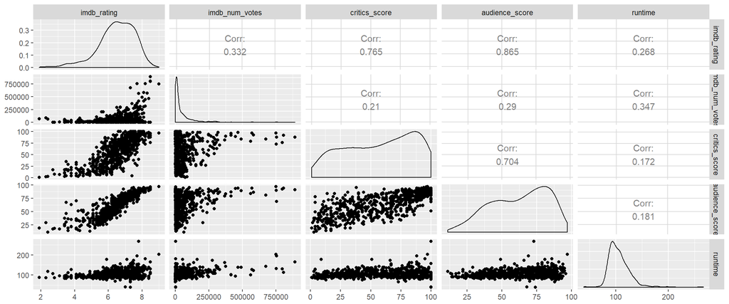

```r
ggpairs(movies_num)
```

Looking at the above correlation matrix, just two variables - “audience_score” and “critics_score” have a strong correlation with “imdb_score”. Although, since the two variables themselves correlate with one another, they are collinear with each other which means that having both variables in the model will not improve the model in any way.

Even though the number of votes variable seems to show a greater number of votes for higher ratings, the relationship is not linear and the variability is rather large.

Runtime also does not appear to be linearly associated with “imdb_ratings” even though there is a slight increase in runtime at higher ratings.

Lets take a closer look at “critics_score” and “audience_score”.

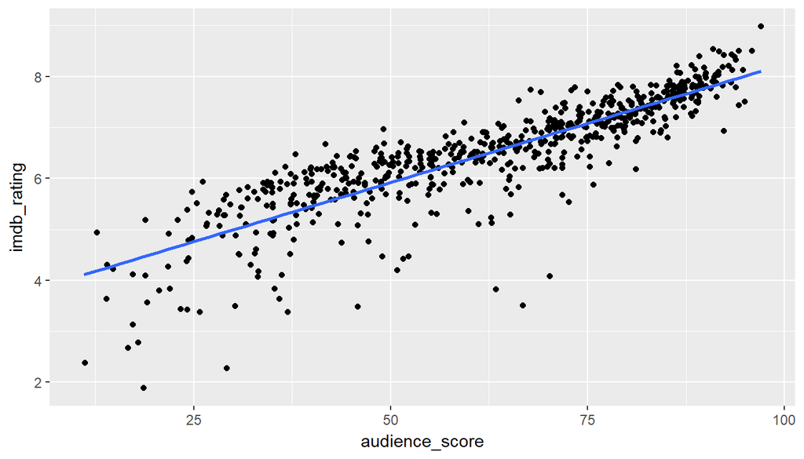

```r
ggplot(data=movies_new,aes(x=audience_score,y=imdb_rating)) +geom_jitter() +geom_smooth(method = "lm", se=FALSE)
```

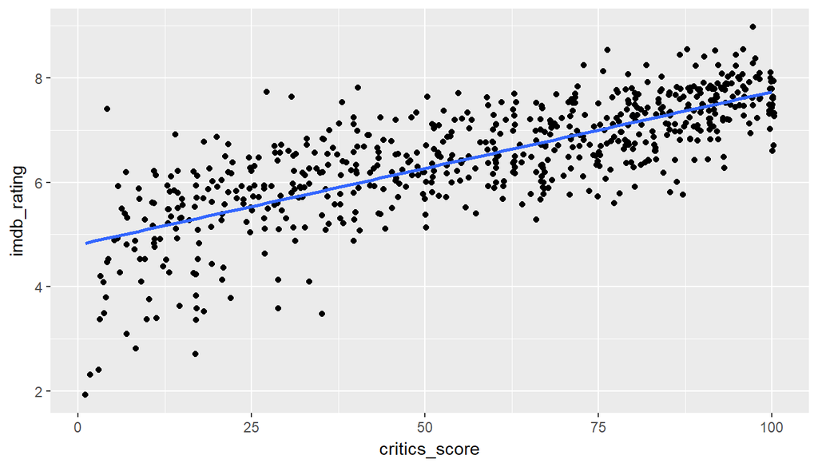

```r
ggplot(data=movies_new,aes(x=critics_score,y=imdb_rating)) +geom_jitter() +geom_smooth(method = "lm", se=FALSE)
```

The above plot shows a moderate, linear and positive relationship with a fairly constant variance.

### Categorical Data Analysis

We now compare each of the remaining (categorical) variables with “imdb_rating”.

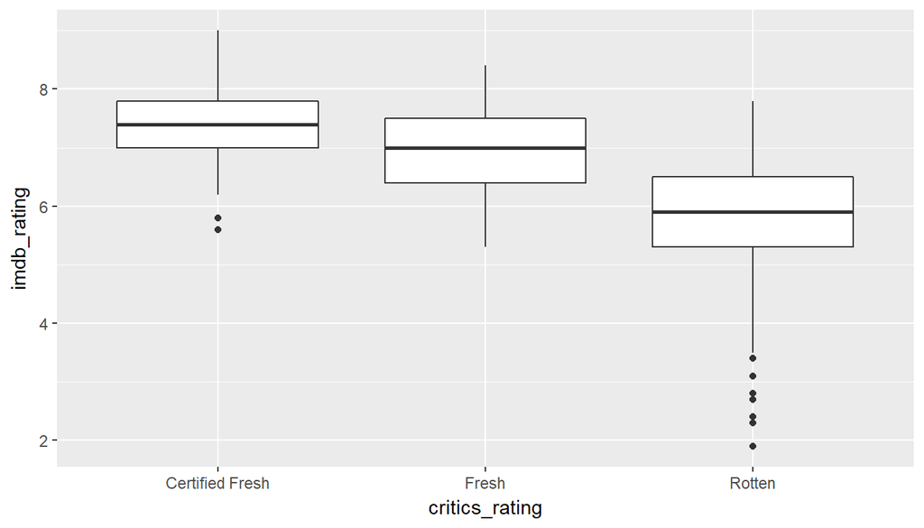

```r
ggplot(data=movies_new,aes(x=critics_rating,y=imdb_rating)) +geom_boxplot()
```

The above boxplot shows the comparison between the “imdb_rating” and the “critics_rating”. This comparison could not be shown as a scatterplot since the rating variable is a categorical one.

However, a clear association can still be observed from the plot as better rated movies by critics tend to correlate with higher ratings on IMDB.

```r
movies_new %>%
  group_by(critics_rating) %>%
  summarise(n())
```

```
## # A tibble: 3 x 2
##    critics_rating `n()`
##            <fctr> <int>
## 1 Certified Fresh   135
## 2           Fresh   209
## 3          Rotten   307
```

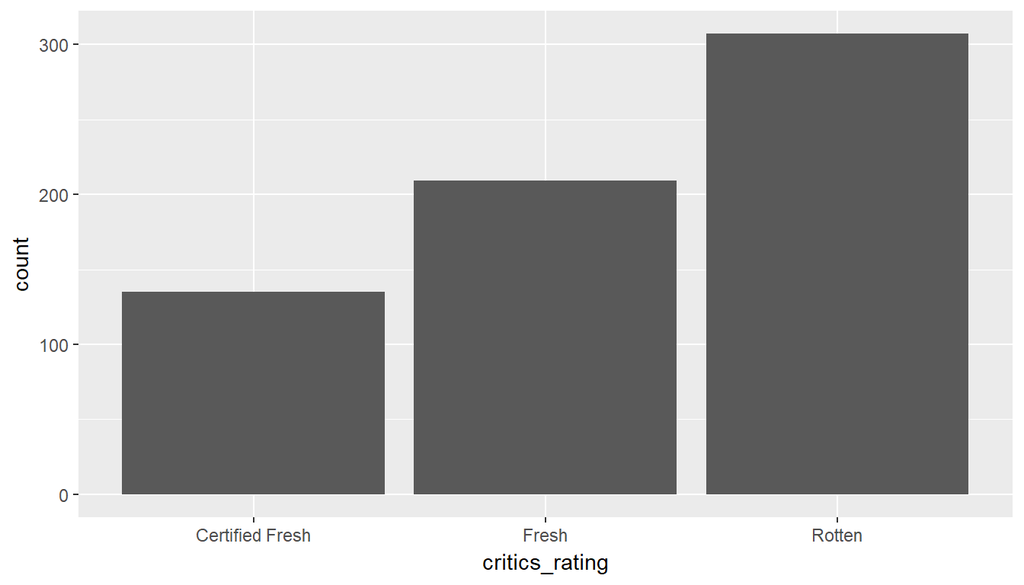

```r
ggplot(data=movies_new,aes(x=critics_rating)) + geom_bar()
```

```r
movies_new %>%
  filter(imdb_rating > 7) %>%
  group_by(critics_rating) %>%
  summarise(n())
```

```
## # A tibble: 3 x 2
##    critics_rating `n()`
##            <fctr> <int>
## 1 Certified Fresh    99
## 2           Fresh   101
## 3          Rotten    24
```

```r
movies_new %>%
  filter(imdb_rating < 6) %>%
  group_by(critics_rating) %>%
  summarise(n())
```

```
## # A tibble: 3 x 2
##    critics_rating `n()`
##            <fctr> <int>
## 1 Certified Fresh     2
## 2           Fresh    17
## 3          Rotten   161
```

The above two summaries show the distribution of critics ratings for IMDB ratings above 7 and below 6 providing more insight into the relation between the two variables.

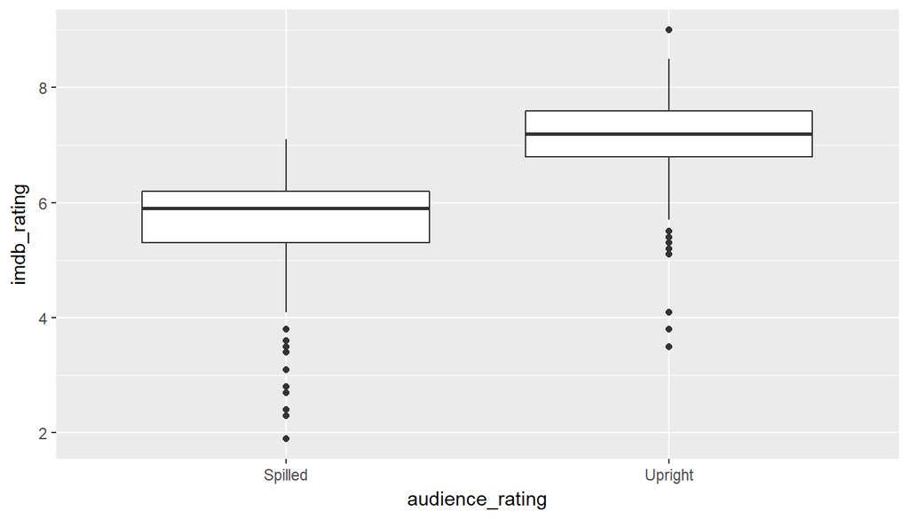

```r
ggplot(data=movies_new,aes(x=audience_rating,y=imdb_rating)) +geom_boxplot()
```

The audience rating shows a similar relation with the IMDB ratings as with the critics variable. Better rated movies by audiences on Rotten Tomatoes seem to positively correlate with the IMDB ratings.

```r
movies_new %>%
  group_by(audience_rating) %>%
  summarise(n())
```

```
## # A tibble: 2 x 2
##   audience_rating `n()`
##            <fctr> <int>
## 1         Spilled   275
## 2         Upright   376
```

```r
movies_new %>%
  filter(imdb_rating < 6) %>%
  group_by(audience_rating) %>%
  summarise(n())
```

```
## # A tibble: 2 x 2
##   audience_rating `n()`
##            <fctr> <int>
## 1         Spilled   164
## 2         Upright    16
```

```r
movies_new %>%
  filter(imdb_rating > 7) %>%
  group_by(audience_rating) %>%
  summarise(n())
```

```
## # A tibble: 2 x 2
##   audience_rating `n()`
##            <fctr> <int>
## 1         Spilled     1
## 2         Upright   223
```

In the summaries above, 57.75% of the movies are given a positive review by the audience in slight contrast to the critics ratings. This shows that the critics are harsher with their ratings, which is expected.

When comparing with IMDB ratings below 6, a massive 91.11% of the audience gave negative reviews while 99.55% of the audience gave positive review to movies with an IMDB rating above 7.

These distributions differ in comparison to the critics ratings in that the audience seem to have an almost unanimous agreement regarding the merit of the film when compared to the IMDB ratings. The critics ratings, on the other hand, seem to be less agreeable with the IMDB ratings. One factor that could be contributing to these results is that the audience ratings are categorized into only 2 levels whie the critics ratings are spread across 3 levels.

The plots below show the relation between the IMDB ratin and whether the movie was nominated for best picture and whether the movie won the award respectively. As expected, movies that were nominated or won show a higher overall distribution.

It will be interesting to see whether these two variables show a high collinearity as that would make including both, redundant.

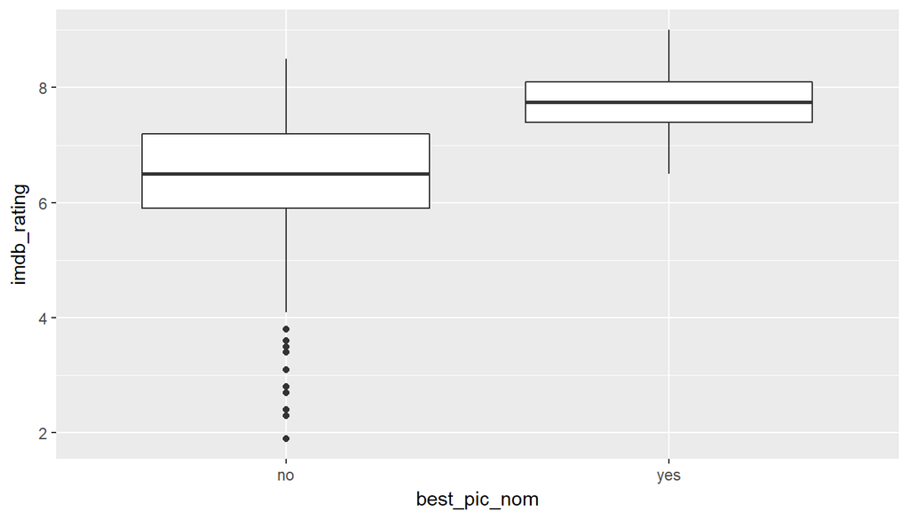

```r
ggplot(data=movies_new,aes(x=best_pic_nom,y=imdb_rating)) +geom_boxplot()
```

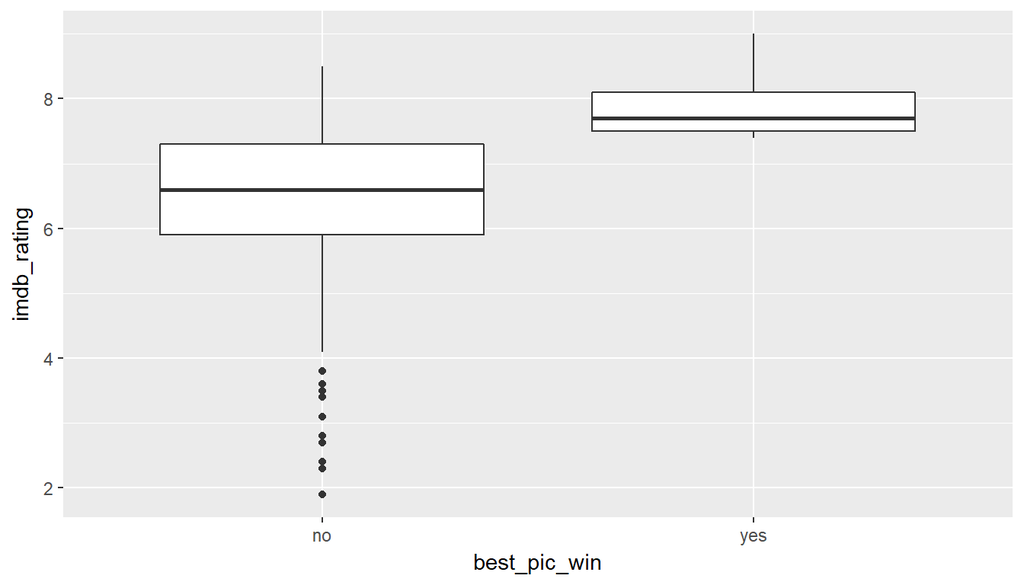

```r
ggplot(data=movies_new,aes(x=best_pic_win,y=imdb_rating)) +geom_boxplot()
```

This is not surprising since each of these explanatory variables only tell us whether the director, actor or actress has ever won an award, not necessarily for the particular movies in this dataset.

If they had won an award for the corresponding movies in this data, we could expect the below distributions to show a stronger correlation between winning and a higher IMDB rating for the movie.

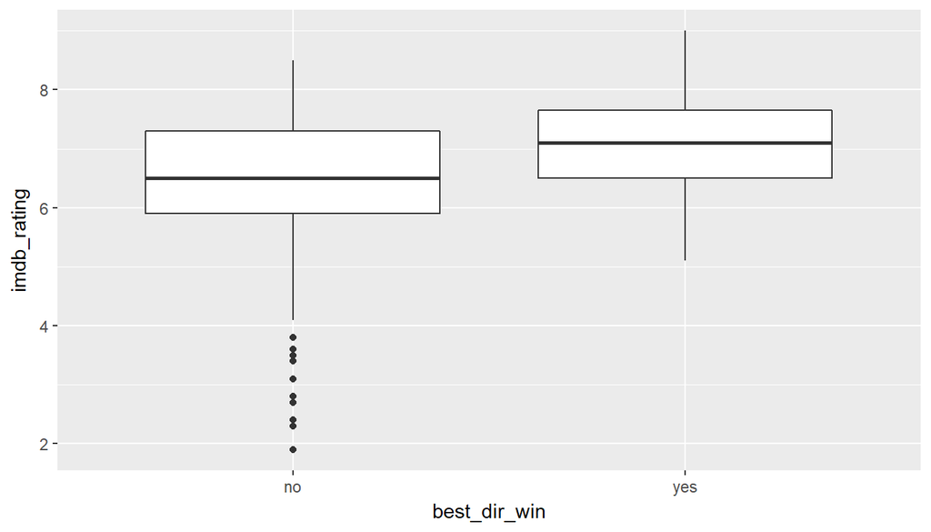

```r
ggplot(data=movies_new,aes(x=best_dir_win,y=imdb_rating)) +geom_boxplot()
```

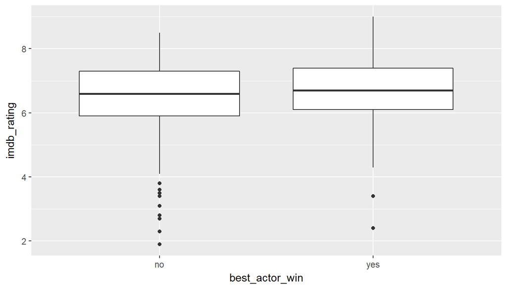

```r
ggplot(data=movies_new,aes(x=best_actor_win,y=imdb_rating)) +geom_boxplot()
```

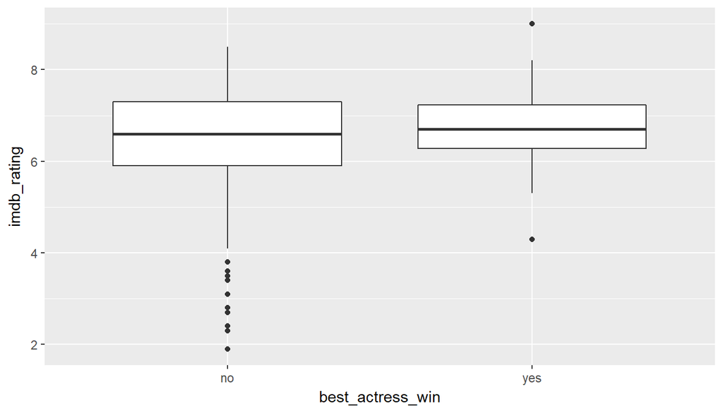

```r
ggplot(data=movies_new,aes(x=best_actress_win,y=imdb_rating)) +geom_boxplot()
```

```r
movies_new %>%
  filter(imdb_rating > 7) %>%
  group_by(best_dir_win,best_actor_win,best_actress_win) %>%
  summarise(n())
```

```
## # A tibble: 8 x 4
## # Groups:   best_dir_win, best_actor_win [?]
##   best_dir_win best_actor_win best_actress_win `n()`
##         <fctr>         <fctr>           <fctr> <int>
## 1           no             no               no   160
## 2           no             no              yes    14
## 3           no            yes               no    19
## 4           no            yes              yes     9
## 5          yes             no               no    12
## 6          yes             no              yes     3
## 7          yes            yes               no     5
## 8          yes            yes              yes     2
```

```r
movies_new %>%
  filter(imdb_rating < 6) %>%
  group_by(best_dir_win,best_actor_win,best_actress_win) %>%
  summarise(n())
```

```
## # A tibble: 5 x 4
## # Groups:   best_dir_win, best_actor_win [?]
##   best_dir_win best_actor_win best_actress_win `n()`
##         <fctr>         <fctr>           <fctr> <int>
## 1           no             no               no   146
## 2           no             no              yes    10
## 3           no            yes               no    16
## 4           no            yes              yes     3
## 5          yes             no               no     5
```

The two tables above show a distribution of the three award variables grouped together with again dividing the IMDB ratings into the less than 6 and greater than 7 segments.

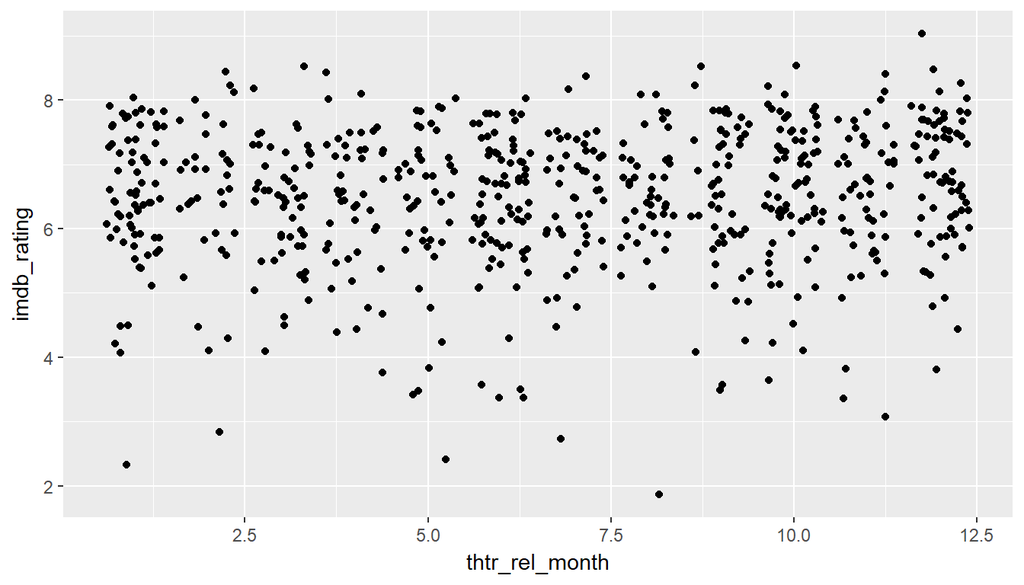

```r
ggplot(data=movies_new,aes(x=thtr_rel_month,y=imdb_rating))+geom_jitter()
```

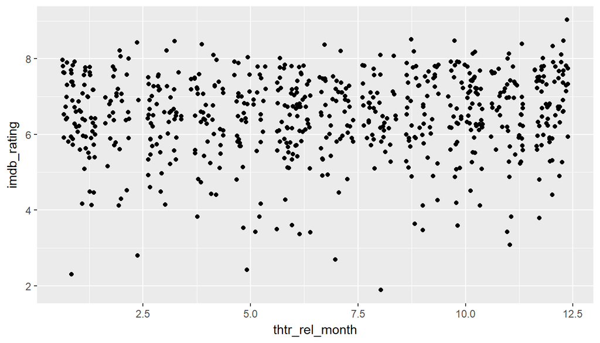

```r
ggplot(data=movies_new,aes(x=thtr_rel_month,y=imdb_rating))+geom_jitter()
```

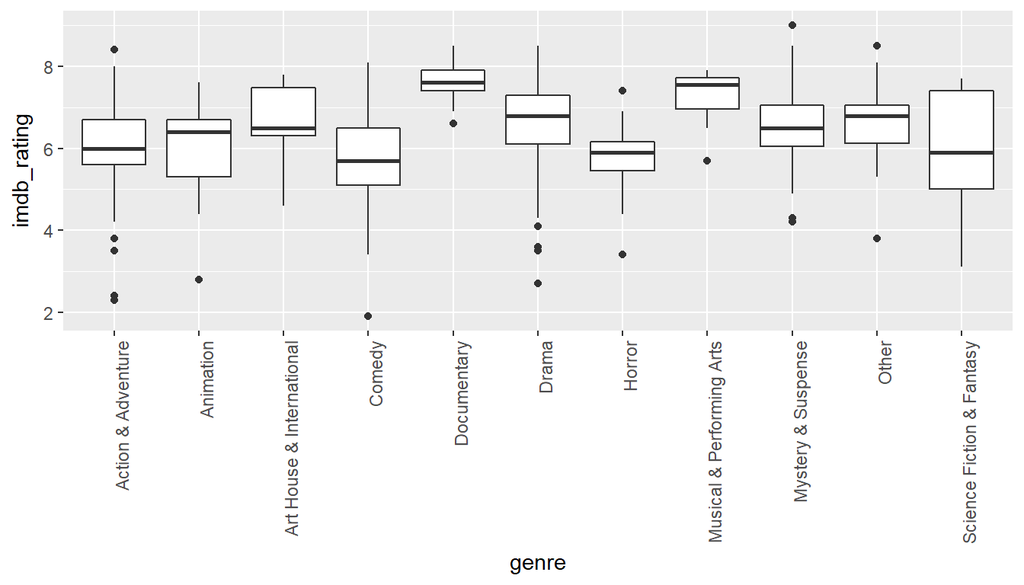

```r
ggplot(data=movies,aes(x=genre,y=imdb_rating))+geom_boxplot() + theme(axis.text.x = element_text(angle=90,hjust=1))
```

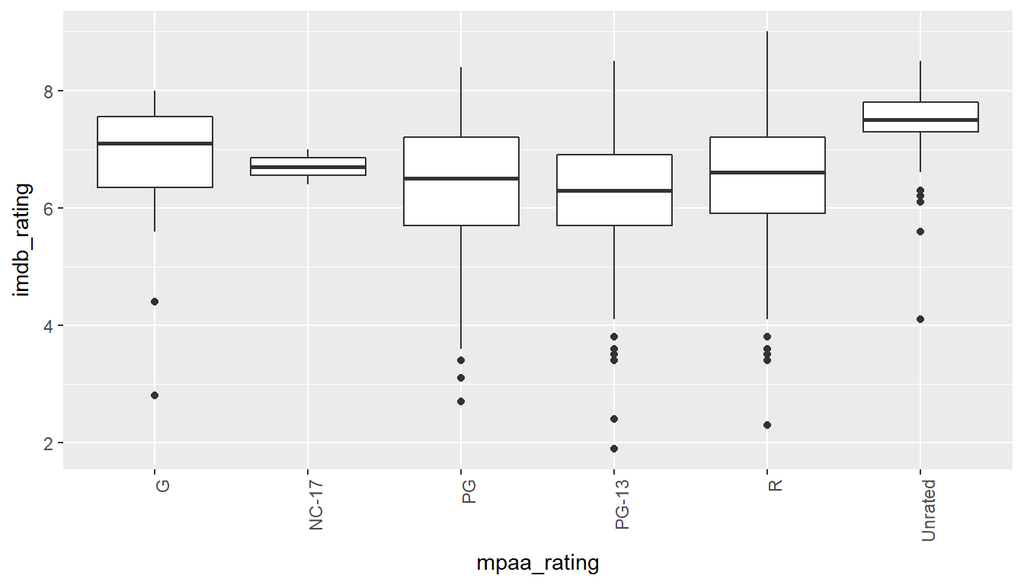

```r
ggplot(data=movies,aes(x=mpaa_rating,y=imdb_rating))+geom_boxplot() + theme(axis.text.x = element_text(angle=90,hjust=1))
```

From the boxplots above containing the distributions of the different genres and MPAA ratings with respect to the IMDB rating, it is not perfectly clear which genres or ratings are significant to the analysis.

Also, there seem to be too many levels for such small differences to make a significant impact on the predictive power of the model.

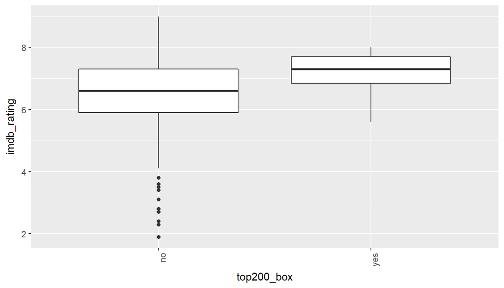

```r
ggplot(data=movies,aes(x=top200_box,y=imdb_rating))+geom_boxplot() + theme(axis.text.x = element_text(angle=90,hjust=1))
```

## Part 4: Modeling

### Variables to omit from the model

Below are the variables and the reasons for their ommissions from the model.

- title: Unrelated to IMDB rating
- title_type: Unrelated to IMDB rating
- studio: Too many studios to provide a single significant contributor
- thtr_rel_year: Unrelated to IMDB rating
- thtr_rel_day: Unrelated to IMDB rating
- dvd_rel_year: Unrelated to IMDB rating
- dvd_rel_day: Unrelated to IMDB rating
- director: Too many directors to provide a significant contributor
- actor1: Too many unique values to provide a significant contributor
- actor2: Too many unique values to provide a significant contributor
- actor3: Too many unique values to provide a significant contributor
- actor4: Too many unique values to provide a significant contributor
- actor5: Too many unique values to provide a significant contributor
- imdb_url: Unrelated to rating
- rt_url: Unrelated to rating

Below are variables ommitted as a result of EDA

### Variables to be included in the model

Response Variable

- imdb_rating

### Creating the multiple linear regression (MLR) model

Below, we create the initial MLR model with the variables of interest.

```r
movies_model <- lm(imdb_rating ~ critics_rating + audience_score + audience_rating + best_pic_win + best_actor_win + best_actress_win + best_dir_win + top200_box,data=movies)

summary(movies_model)
```

```
##
## Call:
## lm(formula = imdb_rating ~ critics_rating + audience_score +
##     audience_rating + best_pic_win + best_actor_win + best_actress_win +
##     best_dir_win + top200_box, data = movies)
##
## Residuals:
##      Min       1Q   Median       3Q      Max
## -2.81911 -0.20653  0.04473  0.30453  1.19650
##
## Coefficients:
##                         Estimate Std. Error t value Pr(>|t|)
## (Intercept)             3.786830   0.124438  30.432  < 2e-16 ***
## critics_ratingFresh    -0.060163   0.059306  -1.014   0.3107
## critics_ratingRotten   -0.385702   0.065852  -5.857 7.53e-09 ***
## audience_score          0.050091   0.002125  23.573  < 2e-16 ***
## audience_ratingUpright -0.438143   0.081131  -5.400 9.38e-08 ***
## best_pic_winyes         0.108855   0.211475   0.515   0.6069
## best_actor_winyes       0.096565   0.058247   1.658   0.0978 .
## best_actress_winyes     0.127633   0.065511   1.948   0.0518 .
## best_dir_winyes         0.114515   0.086500   1.324   0.1860
## top200_boxyes           0.002267   0.136214   0.017   0.9867
## ---
## Signif. codes:  0 '***' 0.001 '**' 0.01 '*' 0.05 '.' 0.1 ' ' 1
##
## Residual standard error: 0.5114 on 641 degrees of freedom
## Multiple R-squared:  0.7808, Adjusted R-squared:  0.7778
## F-statistic: 253.8 on 9 and 641 DF,  p-value: < 2.2e-16
```

A summary of the model is shown above with a R-squared value of 0.7808, adjusted R-squared value of 0.7778 and an overall p-value of less than 2.2e-16.

From these results, we can see that the MLR model as a whole is a significant predictor of the the IMDB rating as the p-value is less than 5%.

Also, the lesser value of the adj R-squared than simply the R-squared value is due to the model taking into consideration all the variables whereby providing a slightly more accurate estimate.

### Model selection

In this project, we will use the Backwards Elimination Method (BEM) using p-values since we are interested in finding the most significant contributor to the IMDB rating.

Hence, first we start with the full model, as already shown above.

In BEM using p-values, we first pick the explanatory variable with the highest p-value and re-fit the model using the remaining variables.

- First iteration

The first iteration of the model shows that the variable “top200_box” has a p-value of 0.9867 which is much larger than 0.05 and is the highest one in the summary shown above.

- Second iteration

```r
movies_model_2 <- lm(imdb_rating ~ critics_rating + audience_score + audience_rating + best_pic_win + best_actor_win + best_actress_win + best_dir_win,data=movies)
summary(movies_model_2)
```

```
##
## Call:
## lm(formula = imdb_rating ~ critics_rating + audience_score +
##     audience_rating + best_pic_win + best_actor_win + best_actress_win +
##     best_dir_win, data = movies)
##
## Residuals:
##      Min       1Q   Median       3Q      Max
## -2.81913 -0.20661  0.04459  0.30452  1.19649
##
## Coefficients:
##                         Estimate Std. Error t value Pr(>|t|)
## (Intercept)             3.786955   0.124112  30.512  < 2e-16 ***
## critics_ratingFresh    -0.060293   0.058742  -1.026   0.3051
## critics_ratingRotten   -0.385822   0.065405  -5.899 5.92e-09 ***
## audience_score          0.050091   0.002123  23.591  < 2e-16 ***
## audience_ratingUpright -0.438119   0.081055  -5.405 9.14e-08 ***
## best_pic_winyes         0.108984   0.211169   0.516   0.6060
## best_actor_winyes       0.096609   0.058141   1.662   0.0971 .
## best_actress_winyes     0.127685   0.065384   1.953   0.0513 .
## best_dir_winyes         0.114523   0.086432   1.325   0.1856
## ---
## Signif. codes:  0 '***' 0.001 '**' 0.01 '*' 0.05 '.' 0.1 ' ' 1
##
## Residual standard error: 0.511 on 642 degrees of freedom
## Multiple R-squared:  0.7808, Adjusted R-squared:  0.7781
## F-statistic: 285.9 on 8 and 642 DF,  p-value: < 2.2e-16
```

In the second iteration, the “best_pic_win” variable has the highest p-value. Therefore, we remove this variable next.

- Third iteration

```r
movies_model_3 <- lm(imdb_rating ~ critics_rating + audience_score + audience_rating + best_actor_win + best_actress_win + best_dir_win,data=movies)
summary(movies_model_3)
```

```
##
## Call:
## lm(formula = imdb_rating ~ critics_rating + audience_score +
##     audience_rating + best_actor_win + best_actress_win + best_dir_win,
##     data = movies)
##
## Residuals:
##      Min       1Q   Median       3Q      Max
## -2.81852 -0.20804  0.04436  0.30623  1.19793
##
## Coefficients:
##                         Estimate Std. Error t value Pr(>|t|)
## (Intercept)             3.788322   0.124013  30.548  < 2e-16 ***
## critics_ratingFresh    -0.065068   0.057976  -1.122   0.2621
## critics_ratingRotten   -0.389462   0.064987  -5.993 3.43e-09 ***
## audience_score          0.050123   0.002121  23.630  < 2e-16 ***
## audience_ratingUpright -0.438603   0.081003  -5.415 8.68e-08 ***
## best_actor_winyes       0.096427   0.058107   1.659   0.0975 .
## best_actress_winyes     0.131689   0.064885   2.030   0.0428 *
## best_dir_winyes         0.128527   0.082015   1.567   0.1176
## ---
## Signif. codes:  0 '***' 0.001 '**' 0.01 '*' 0.05 '.' 0.1 ' ' 1
##
## Residual standard error: 0.5107 on 643 degrees of freedom
## Multiple R-squared:  0.7808, Adjusted R-squared:  0.7784
## F-statistic: 327.1 on 7 and 643 DF,  p-value: < 2.2e-16
```

The summary for the third iteration above shows one of the levels of “critics_ratings” as being the least significant p-value. Although, since the “Rotten” level has a significant p-value, we keep the entire variable in the model.

We remove the next least significant variable which is “best_dir_win”.

- Fourth iteration

```r
movies_model_4 <- lm(imdb_rating ~ critics_rating + audience_score + audience_rating + best_actor_win + best_actress_win,data=movies)
summary(movies_model_4)
```

```
##
## Call:
## lm(formula = imdb_rating ~ critics_rating + audience_score +
##     audience_rating + best_actor_win + best_actress_win, data = movies)
##
## Residuals:
##      Min       1Q   Median       3Q      Max
## -2.81937 -0.20841  0.04048  0.29878  1.19754
##
## Coefficients:
##                         Estimate Std. Error t value Pr(>|t|)
## (Intercept)             3.792692   0.124122  30.556  < 2e-16 ***
## critics_ratingFresh    -0.067718   0.058016  -1.167   0.2436
## critics_ratingRotten   -0.398069   0.064827  -6.140 1.44e-09 ***
## audience_score          0.050301   0.002121  23.721  < 2e-16 ***
## audience_ratingUpright -0.445447   0.080977  -5.501 5.45e-08 ***
## best_actor_winyes       0.104415   0.057948   1.802   0.0720 .
## best_actress_winyes     0.138342   0.064819   2.134   0.0332 *
## ---
## Signif. codes:  0 '***' 0.001 '**' 0.01 '*' 0.05 '.' 0.1 ' ' 1
##
## Residual standard error: 0.5112 on 644 degrees of freedom
## Multiple R-squared:  0.7799, Adjusted R-squared:  0.7779
## F-statistic: 380.4 on 6 and 644 DF,  p-value: < 2.2e-16
```

The next variable to be removed is “best_actor_win” which has a p-value of 0.072.

```r
movies_model_5 <- lm(imdb_rating ~ critics_rating + audience_score + audience_rating + best_actress_win,data=movies)
summary(movies_model_5)
```

```
##
## Call:
## lm(formula = imdb_rating ~ critics_rating + audience_score +
##     audience_rating + best_actress_win, data = movies)
##
## Residuals:
##      Min       1Q   Median       3Q      Max
## -2.82851 -0.21101  0.03578  0.31413  1.18725
##
## Coefficients:
##                         Estimate Std. Error t value Pr(>|t|)
## (Intercept)             3.798919   0.124290  30.565  < 2e-16 ***
## critics_ratingFresh    -0.065649   0.058106  -1.130   0.2590
## critics_ratingRotten   -0.398931   0.064938  -6.143 1.41e-09 ***
## audience_score          0.050491   0.002122  23.798  < 2e-16 ***
## audience_ratingUpright -0.454348   0.080966  -5.612 2.98e-08 ***
## best_actress_winyes     0.154321   0.064321   2.399   0.0167 *
## ---
## Signif. codes:  0 '***' 0.001 '**' 0.01 '*' 0.05 '.' 0.1 ' ' 1
##
## Residual standard error: 0.5121 on 645 degrees of freedom
## Multiple R-squared:  0.7788, Adjusted R-squared:  0.7771
## F-statistic: 454.2 on 5 and 645 DF,  p-value: < 2.2e-16
```

The model above should be the final model consisting of the following explanatory variables:

- critics_rating
- audience_rating
- audience_score
- best_actress_win

Since the critics rating variable still has a level that shows an insignificant p-value, we can check the model using ANOVA to analyze the variable as a whole.

```r
anova(movies_model_5)
```

```
## Analysis of Variance Table
##
## Response: imdb_rating
##                   Df  Sum Sq Mean Sq   F value    Pr(>F)
## critics_rating     2 309.305 154.653  589.6338 < 2.2e-16 ***
## audience_score     1 276.575 276.575 1054.4792 < 2.2e-16 ***
## audience_rating    1   8.275   8.275   31.5491 2.893e-08 ***
## best_actress_win   1   1.510   1.510    5.7563   0.01671 *
## Residuals        645 169.174   0.262
## ---
## Signif. codes:  0 '***' 0.001 '**' 0.01 '*' 0.05 '.' 0.1 ' ' 1
```

The ANOVA table above shows that all the variables remaining in the final linear model are significant as the p-values, with respect to the F-statistic, are less than 0.05.

### Model Diagnostics

We have one numerical variable in our model - “audience_score”. The model can be tested creating a scatter plot between this variable and the residuals.

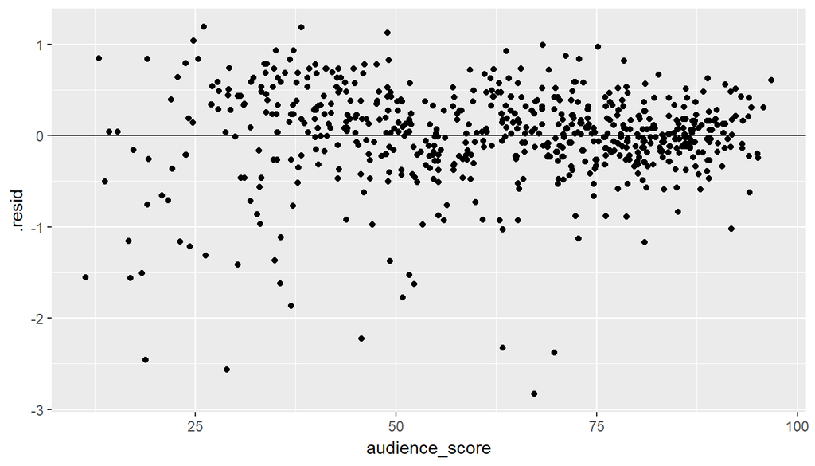

```r
ggplot(data=movies_model_5,aes(x=audience_score,y=.resid)) + geom_jitter() + geom_hline(yintercept = 0)
```

Note that the variability in residual values seem to be higher at the lower scores. Although, the scatter seems to be randomly distributed about the 0 y-intercept.

2. Nearly normal residuals

In order to check for normality, we create a histogram of residuals as shown below.

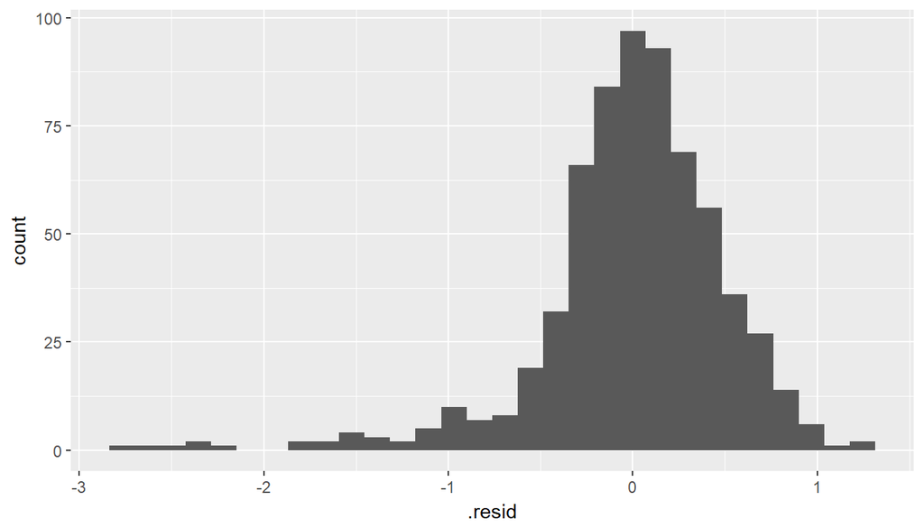

```r
ggplot(data=movies_model_5,aes(x=.resid)) + geom_histogram(bins=30)
```

As seen from the histogram above, the residuals have a unimodal shape and are normally distributed around a mean of 0, even though the distribution is slightly left skewed.

Below is a normal probablity plot of the residuals. The left skewness of the distribution can be seen at the lower end of the plot where the tail seems to drop off from the guided line.

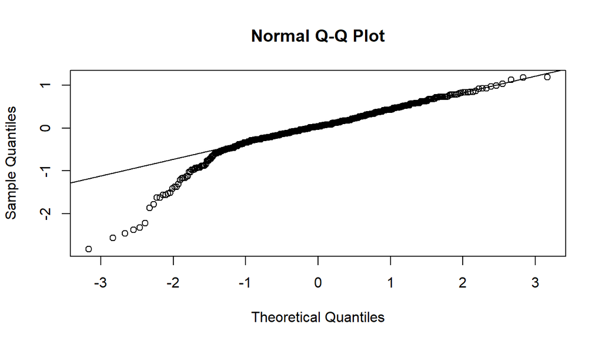

```r
qqnorm(movies_model_5$residuals)
qqline(movies_model_5$residuals)
```

3. Constant variability of the residuals

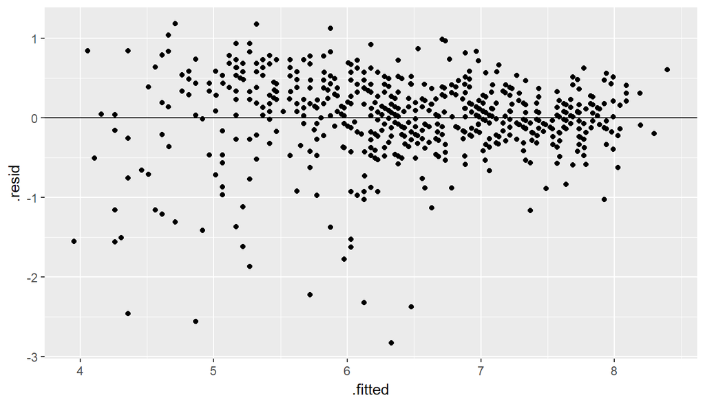

```r
ggplot(data=movies_model_5,aes(x=.fitted,y=.resid))+geom_jitter() + geom_hline(yintercept = 0)
```

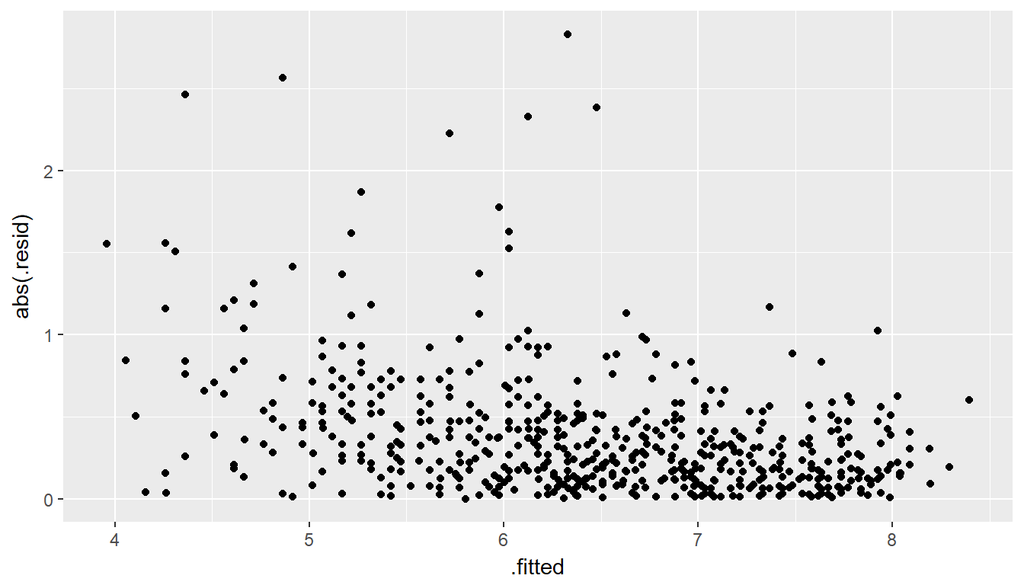

```r
ggplot(data=movies_model_5,aes(x=.fitted,y=abs(.resid)))+geom_jitter()
```

The first plot above shows the relation between the fitted values of the model and the residuals of the model.

From the residual plot, it can be seen that the data does not show constant variability throughout as the variability is higher at lower fitted values as compared higher values.

The second plot above shows the absolute values of the residuals against the fitted values to observe any unusual data points. The points that are higher than 1 on the y axis could be considered unusual or outliers, but are still crucial to the diagnostics of the model.

4. Independent residuals

Since the movies in this dataset were selected randomly (random sampling), we can assume that the residuals are independent as well as the residuals will also be independent of one another.

## Part 5: Prediction

In order to put the linear model into practice, we test it on the movie “Dr. Strange” which was released in November of 2016.

We create a new data frame containing the observations for the model variables corresponding to the movie and make the prediction using the fitted model as shown below.

```r
dr_strange <- data.frame(critics_rating="Certified Fresh",audience_score=86,audience_rating="Upright",best_actress_win="no")

predict(movies_model_5,dr_strange)
```

```
##        1
## 7.686768
```

After running the prediction function using the real movie values, we get a predicted IMDB score of 7.686768 for Dr. Strange. The actual IMDB rating is 7.5. Hence, the prediction is not too far off.

```r
predict(movies_model_5,dr_strange,interval = "prediction",level=0.95)
```

```
##        fit      lwr     upr
## 1 7.686768 6.676916 8.69662
```

Using the data for “Dr. Strange”, we get a prediction interval of 6.676916 to 8.69662.

Hence, the model predicts, with 95% confidence, that a movie with “Certified Fresh” critics_rating, 86 audience_score, “Upright” audience_rating an no best actress win is expected to have an IMDB rating between 6.676916 and 8.69662. This range of values represents the uncertainty of prediction in the model.

### References for Dr. Strange prediction data

Rotten Tomatoes: https://www.rottentomatoes.com/m/doctor_strange_2016/

IMDB: http://www.imdb.com/title/tt1211837/

## Part 6: Conclusion

### Model diagnostics

Following the backward elimination method using the p-value, the final model consisted of 4 explanatory variables.

The adjusted R-squared of the model came out to be 0.7771 which is a fairly high value. This tells us that 77.71% of the variability in the IMDB ratings can be estimated by the model.

The residuals of the model have a unmidal and normal distribution except for a slight left-skewness which can also be observed in the normal probability plot.

Finally, the constant variability condition is also not met since the residuals versus fitted values plot seems to exhibit a fan-shaped scatter plot.

The residuals are independent of one another since the initial data was randomly selected.

One reason the model diagnostics conditions were not met could be because we optimized the model for finding the most significant contributors using p-values as opposed to optimizing for the adjusted R-squared.

Another reason could have been excluding certain other variables to the model which could have provided better model diagnostics.

### Most significant predictors

According to the linear model, “audience_score” is the most significant predictor of the IMDB rating for a particular movie with p value of < 2e-16.

Hence, this is the most crucial variable in the model in making an accurate prediction of an IMDB movie rating. This is not surprising since a particular movie is likely to garner the same reputation on any movie platform.

### Prediction

The movie from 2016 that was chosen for testing the model was “Dr. Strange”. Including the values for the movie in the model yielded a fairly accurate prediction of the actual IMDB rating which fell within the prediction interval and was close to the single prediction value as well.

### Future work

It would be useful and interesting to optimize the model for the highest predictive power using the R-squared method. This could improve the model diagnostics results as mentioned above.

This could also provide a higher adjusted R-squared and as a result, an even better prediction. Other things to try would be to use forward stepping instead of backward elimination during the model selection process to see if that makes any difference to the characteristics of the model.

Also, it will be interesting to see how the prediction works if we picked a movie that does not have favourable reviews on Rotten Tomatoes, as we have seen that the residuals versus fitted scatter plot has a higher variability for lower fitted values.